# Did Paychecks Keep Up With Prices?

Paychecks are up 32% since COVID began, but prices rose 29%. The real raise: less than a dollar an hour.

Data Viz

inflation

Python

Author

Michael Li

Published

October 4, 2026

## Why I looked at this

In 2022 it felt like everyone I knew was complaining about prices: rent, groceries, gas. But a lot of people also got big raises around then. So which one won?

**My question: since COVID started, have paychecks kept up with prices, and did some industries do better than others?**

**The short answer: barely.** The average paycheck has grown 32% since February 2020, but prices grew 29%, so an hour of work buys only about 3% more than it did before COVID.

This matters because your paycheck number isn’t what you live on. If your pay rises 10% but prices rise 15%, you can buy less than before. Economists call the paycheck number the *nominal* wage and what it buys the *real* wage, the one people actually feel.

## Data

My data comes from the Bureau of Labor Statistics via FRED: average hourly earnings for private-sector workers, overall and for 13 industries, plus the Consumer Price Index (CPI), all monthly and seasonally adjusted.

I compare February 2020, the last month before COVID hit, with August 2026, the newest month with both series when I downloaded the data. My code downloads each series once and saves it in `data/raw/`, so results stay the same every time I render.

```python
import os
import pandas as pd
import matplotlib.pyplot as plt

for folder in ["data/raw", "data/processed", "results/figures", "results/tables"]:
    os.makedirs(folder, exist_ok=True)

# download a series from FRED once, then reuse the saved csv
def get_fred(series_id):
    path = "data/raw/" + series_id + ".csv"
    if not os.path.exists(path):
        url = "https://fred.stlouisfed.org/graph/fredgraph.csv?id=" + series_id
        pd.read_csv(url).to_csv(path, index=False)
    df = pd.read_csv(path)
    df.columns = ["date", "value"]
    df["date"] = pd.to_datetime(df["date"])
    return df

wages = get_fred("CES0500000003").rename(columns={"value": "wage"})
cpi = get_fred("CPIAUCSL").rename(columns={"value": "cpi"})
```

## Adjusting for inflation: the one transformation that matters

A dollar in 2026 doesn’t buy what it did in 2020, so the one transformation that really matters is taking inflation out. The basic idea fits in one line:

`real income growth ≈ nominal income growth - inflation`

In plain words, your raise minus the rise in prices is how much better off you really are. So in my example above, a 10% raise with 15% inflation means real pay falls roughly 5%.

That shortcut is fine for one year, but over several years it overstates the gain a little (since 2020 it would give 3.4% instead of the exact 2.7%). So to compare pay across years, I turned every month’s wage into August 2026 dollars:

`real wage = wage * CPI(Aug 2026) / CPI(that month)`

I also calculated 12-month growth rates, which is how inflation is usually reported in the news. Figure 1 and Figure 3 use the real wage, and Figure 2 compares the two growth rates.

```python
df = wages.merge(cpi, on="date")

# growth compared to the same month last year (%)
df["wage_growth"] = (df["wage"] / df["wage"].shift(12) - 1) * 100
df["inflation"] = (df["cpi"] / df["cpi"].shift(12) - 1) * 100

# keep Jan 2019 to Aug 2026
df = df[(df["date"] >= "2019-01-01") & (df["date"] <= "2026-08-01")].copy()

# real wage in August 2026 dollars
latest_cpi = df["cpi"].iloc[-1]
df["real_wage"] = df["wage"] * latest_cpi / df["cpi"]

df.to_csv("data/processed/wages_cpi_clean.csv", index=False)

# any missing months?
df[df["cpi"].isna()]
```

```
          date   wage  cpi  wage_growth  inflation  real_wage
235 2025-10-01  36.85  NaN      3.91991        NaN        NaN
```

One thing I noticed: October 2025 has no CPI, because the government shutdown stopped BLS from collecting prices that month. I left it blank instead of making up a number, which is why the lines have a small gap.

## What I found

```python
feb20 = df[df["date"] == "2020-02-01"].iloc[0]
aug26 = df[df["date"] == "2026-08-01"].iloc[0]

pay_change = (aug26["wage"] / feb20["wage"] - 1) * 100
price_change = (aug26["cpi"] / feb20["cpi"] - 1) * 100
real_change = (aug26["real_wage"] / feb20["real_wage"] - 1) * 100

summary = pd.DataFrame({
    "measure": ["pay change (%)", "price change (%)", "real pay change (%)"],
    "value": [pay_change, price_change, real_change]
}).round(1)
summary.to_csv("results/tables/summary.csv", index=False)
#real gain for a full time worker
yearly_gain = (aug26["real_wage"] - feb20["real_wage"]) * 2080
print("Real gain per year, full-time worker: $", round(yearly_gain))
```

```
Real gain per year, full-time worker: $ 2031
```

```python
summary
```

```
               measure  value
0       pay change (%)   32.3
1     price change (%)   28.9
2  real pay change (%)    2.7
```

Since February 2020, average pay went up 32.3%. That sounds great until you see that prices went up 28.9% too. So the real raise is only about 2.7% over six and a half years. (All numbers here come from the tables my code saves in `results/tables/`.)

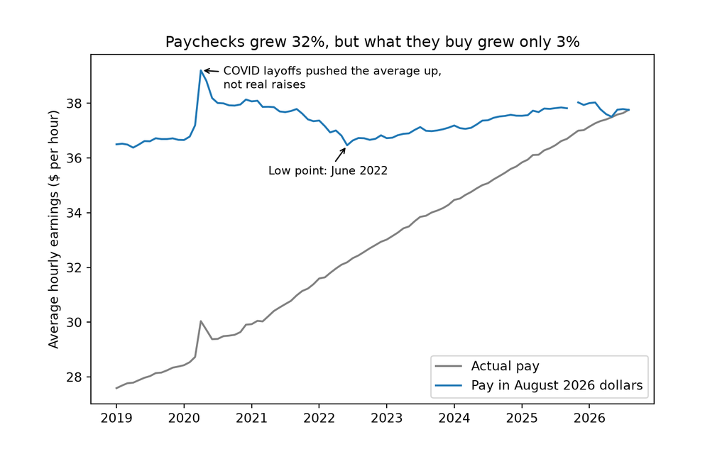

Figure 1: Average hourly earnings of private-sector workers, actual and in August 2026 dollars. Source: BLS via FRED (CES0500000003, CPIAUCSL).

```python
plt.figure(figsize=(8, 5))
plt.plot(df["date"], df["wage"], color="gray", label="Actual pay")
plt.plot(df["date"], df["real_wage"], color="tab:blue", label="Pay in August 2026 dollars")
#label the two key moments
spike = df[df["date"] == "2020-04-01"].iloc[0]
low = df[df["date"] == "2022-06-01"].iloc[0]
plt.annotate("COVID layoffs pushed the average up,\nnot real raises",
             xy=(spike["date"], spike["real_wage"]), xytext=(pd.Timestamp("2020-08-01"), 38.55),
             arrowprops=dict(arrowstyle="->"), fontsize=9)
plt.annotate("Low point: June 2022",
             xy=(low["date"], low["real_wage"]), xytext=(pd.Timestamp("2021-04-01"), 35.4),
             arrowprops=dict(arrowstyle="->"), fontsize=9)
plt.title("Paychecks grew 32%, but what they buy grew only 3%")
plt.ylabel("Average hourly earnings ($ per hour)")
plt.legend()
plt.savefig("results/figures/fig1_real_wage.png", dpi=300)
plt.show()
```

In Figure 1, the gray line is the actual paycheck: $28.54 an hour in February 2020 and $37.76 in August 2026. The blue line shows what that pay can buy, and it’s much flatter: in today’s dollars, the February 2020 wage was worth $36.78, so the real gain is under a dollar an hour. For someone working full time, that’s only about $2,000 a year in extra buying power after six and a half years.

The jump in spring 2020 isn’t a raise. Millions of low-paid workers lost their jobs, so the average pay of those still working shot up. Real pay then slid during the inflation surge and bottomed out in June 2022, a bit below where it started.

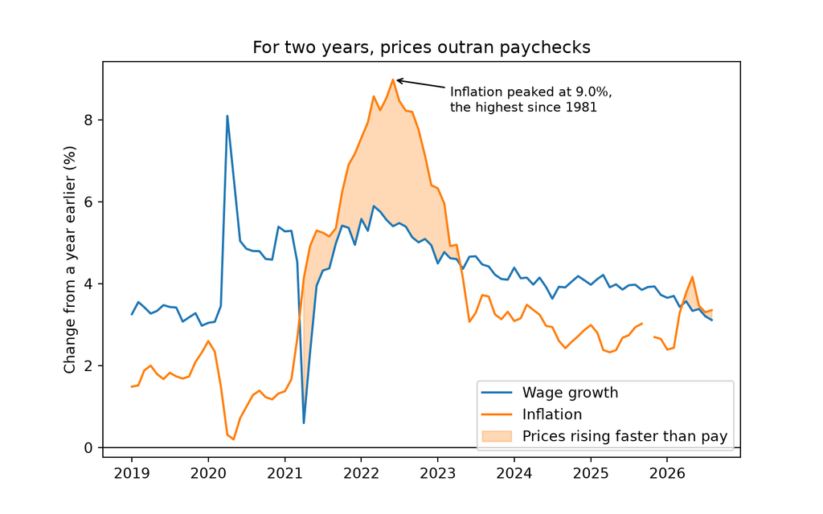

Figure 2: Wage growth and inflation, each compared with the same month a year earlier. Source: BLS via FRED (CES0500000003, CPIAUCSL). No CPI was published for October 2025.

```python
plt.figure(figsize=(8, 5))
plt.plot(df["date"], df["wage_growth"], color="tab:blue", label="Wage growth")
plt.plot(df["date"], df["inflation"], color="tab:orange", label="Inflation")
plt.fill_between(df["date"], df["wage_growth"], df["inflation"],
                 where=df["inflation"] > df["wage_growth"],
                 color="tab:orange", alpha=0.3, label="Prices rising faster than pay")
plt.axhline(0, color="black", linewidth=0.8)
#label the peak
peak = df[df["date"] == "2022-06-01"].iloc[0]
plt.annotate("Inflation peaked at 9.0%,\nthe highest since 1981",
             xy=(peak["date"], peak["inflation"]), xytext=(pd.Timestamp("2023-03-01"), 8.2),
             arrowprops=dict(arrowstyle="->"), fontsize=9)
plt.title("For two years, prices outran paychecks")
plt.ylabel("Change from a year earlier (%)")
plt.legend(loc="lower right")
plt.savefig("results/figures/fig2_growth_vs_inflation.png", dpi=300)
plt.show()
```

```python
# number of months each year when prices won
df["prices_won"] = df["inflation"] > df["wage_growth"]
df.groupby(df["date"].dt.year)["prices_won"].sum()
```

```
date
2019     0
2020     0
2021     9
2022    12
2023     4
2024     0
2025     0
2026     5
Name: prices_won, dtype: int64
```

Think of Figure 2 as a race: in the shaded months, prices grew faster than pay. Inflation peaked at 9.0% in June 2022 (the famous 9.1% is before seasonal adjustment). That was the fastest inflation since 1981. Wages grew around 5% a year, which wasn’t enough, so prices won every month from April 2021 to April 2023. Wages pulled ahead after that, but since April 2026 prices have been slightly ahead again.

To see who did best, I repeated the February 2020 vs. August 2026 comparison for each industry, taking out the 28.9% rise in prices.

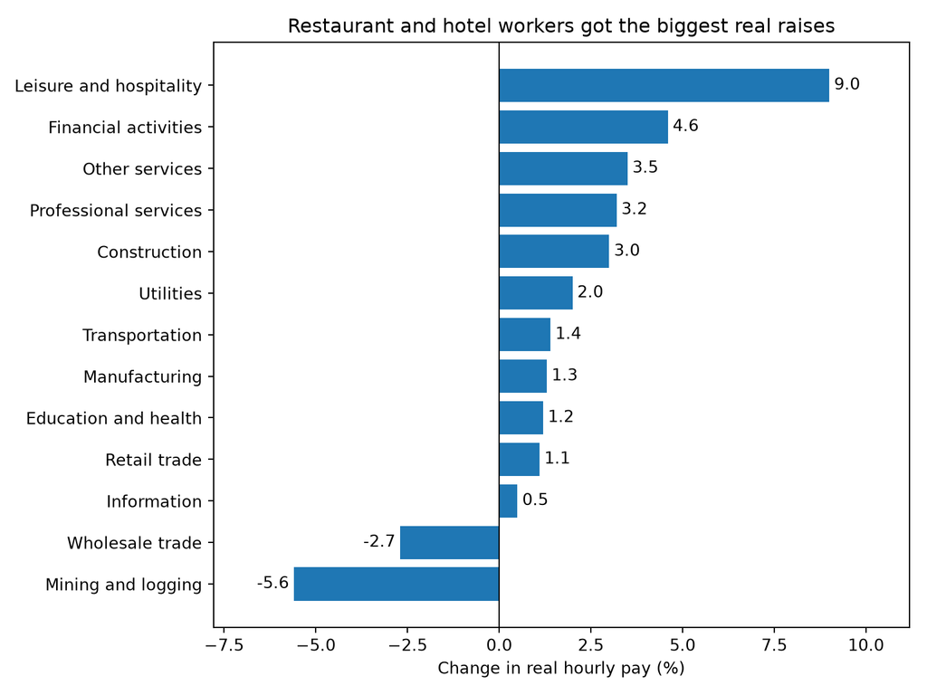

Figure 3: Change in real average hourly earnings by industry, February 2020 to August 2026. Source: BLS via FRED (CES industry series, CPIAUCSL).

```python
industries = {
    "Mining and logging": "CES1000000003",
    "Construction": "CES2000000003",
    "Manufacturing": "CES3000000003",
    "Wholesale trade": "CES4142000003",
    "Retail trade": "CES4200000003",
    "Transportation": "CES4300000003",
    "Utilities": "CES4422000003",
    "Information": "CES5000000003",
    "Financial activities": "CES5500000003",
    "Professional services": "CES6000000003",
    "Education and health": "CES6500000003",
    "Leisure and hospitality": "CES7000000003",
    "Other services": "CES8000000003",
}

price_ratio = aug26["cpi"] / feb20["cpi"]

rows = []
for name, series_id in industries.items():
    ind = get_fred(series_id)
    start = ind[ind["date"] == "2020-02-01"]["value"].iloc[0]
    end = ind[ind["date"] == "2026-08-01"]["value"].iloc[0]
    change = ((end / start) / price_ratio - 1) * 100
    rows.append([name, start, end, round(change, 1)])

by_industry = pd.DataFrame(rows, columns=["industry", "wage_feb2020", "wage_aug2026", "real_change"])
by_industry = by_industry.sort_values("real_change")
by_industry.to_csv("results/tables/real_change_by_industry.csv", index=False)

plt.figure(figsize=(8, 6))
bars = plt.barh(by_industry["industry"], by_industry["real_change"], color="tab:blue")
plt.bar_label(bars, fmt="%.1f", padding=3)
plt.axvline(0, color="black", linewidth=0.8)
plt.margins(x=0.15)
plt.title("Restaurant and hotel workers got the biggest real raises")
plt.xlabel("Change in real hourly pay (%)")
plt.tight_layout()
plt.savefig("results/figures/fig3_industries.png", dpi=300)
plt.show()
```

Figure 3 shows that almost every industry came out a little ahead, but leisure and hospitality (restaurants, hotels, bars) stands out at +9.0%. It was also the lowest-paid industry before COVID ($16.92 an hour), and it probably raised pay the most because restaurants and hotels struggled to hire when things reopened in 2021. Only mining and logging (-5.6%) and wholesale trade (-2.7%) fell behind. For a full-time worker in leisure and hospitality, the real raise comes to roughly $4,000 a year.

## Limits

These are averages, so they don’t describe every worker, and they leave out benefits, hours, and taxes. The CPI is an average basket too, so your own inflation could be different. And this shows what happened, not exactly why.

## Takeaway

So, did paychecks keep up? **Yes, but barely.** Pay rose 32.3% and prices rose 28.9%, leaving a real raise of about 2.7%, less than a dollar an hour. Workers fell behind for two years during the inflation surge, slowly caught up, and lower-paid industries like restaurants and hotels did best.

The biggest lesson for me is that a raise only means something next to the inflation rate. A 5% raise in 2022 was actually a pay cut, while a 4% raise in 2024 was a real gain. That’s why so many people felt poorer in 2022 even though their paychecks were growing. And with prices edging ahead of pay again in 2026, the next few months are worth watching.

*Data source: U.S. Bureau of Labor Statistics, via FRED (Federal Reserve Bank of St. Louis): average hourly earnings for all private-sector employees ([`CES0500000003`](https://fred.stlouisfed.org/series/CES0500000003)) and 13 industries (`CES1000000003` to `CES8000000003`), and the CPI-U ([`CPIAUCSL`](https://fred.stlouisfed.org/series/CPIAUCSL)), all monthly and seasonally adjusted. BLS data are public domain. Read programmatically from FRED’s CSV links on October 4, 2026 and cached in `data/raw/`. The wage numbers come from the BLS’s monthly survey of employers (Current Employment Statistics), and the CPI-U covers urban consumers, over 90% of the U.S. population. Code to reproduce the analysis is in the [GitHub repository](https://github.com/LeeBABA999/aeds-website/tree/main/blog/posts/post4).*